# Seminarska naloga

Bayesova statistika

Alen Kahteran

30. 3. 2020

# Uvod

V sklopu seminarske naloge bomo primerjali frekventistični način linearnega modela ter Bayesov načein linearnega modela. V prvem sklopu primerjamo načina na simuliranih podatkih, nato pa še preverimo kako se Bayesov način obnese na pravih podatkih. Podatki, ki sem si jih izbral za drugi sklop so podatki o ameriških avtomobilih med leti $1970$ in $1982$. Predstavljajo različne avte, ter nekaj njihovih lastnosti. Na enakem podatkovju na koncu zgradimo še hierarhični model, kjer bomo primerjali razlike v letu izdelave.

# Primerjava robustnosti `lm()` in `bayesx()` s simulacijami

V temu sklopu bomo primerjali dva načina na treh različnih scenarijih in namreč

1. normalno porazdeljena napaka z majhno varianco (v našem primeru $\sigma = 3$)
2. normalno porazdeljena napaka z veliko varianco (v našem primeru $\sigma = 50$)
3. asimetrično porazdeljena napaka (v našem primeru $\epsilon \sim \chi^2_{df=1}$)

Pri vsakem izmed scenarijev velja naslednje:

- Velikost vzorca je $100$
- Št. ponovitev je $1000$
- Generiramo 5 različnih spremenljivk.
- Vsako spremenljivko generiramo neodvisno eno od druge, in s tremi različnimi porazdelitvami.

Naključno generirani podatki se porazdeljujejo po:

- $X_1 \sim N(10,9)$
- $X_2 \sim Bern(0.6)$
- $X_3 \sim N(10,16)$
- $X_4 \sim \chi^2_{df=2}$
- $X_5 \sim N(10,25)$

spremenljivka $Y$ bo torej generirana kot

$$Y = \beta_0 + \beta_1 X_1 + \beta_2 X_2 + \beta_3 X_3 + \beta_4 X_4 + \beta_5 X_5 + \epsilon$$

Za vsak posamezen scenarij bomo za eno simulacijo preverili konvergenco.

## Konvergenca

Kot omenjeno že prej je naša napaka v teh primerih različna in sicer v primeru normalne z majhno varianco $\epsilon \sim N(0, 9)$, v primeru normalne z veliko varianco $\epsilon \sim N(0, 50^2)$ in v primeru asimetrične napake $\epsilon \sim \chi^2_{df=1}$. Na kratko si poglejmo MCMC verige posamičnih koeficientov z različnimi napakami. Potrebno je vedeti da je tu že uporabljen *burn-in* velikosti $2000$ ter *thinning* velikosti $10$, št. iteracij je pred obema postopkoma bil $12000$. Še manjši opomnik, da “kvaliteto” scenarija težko primerjamo iz ene same verige, saj so tu na grafih različne *y* osi.

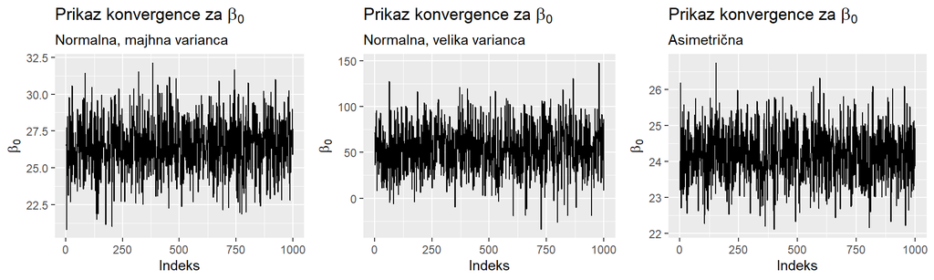

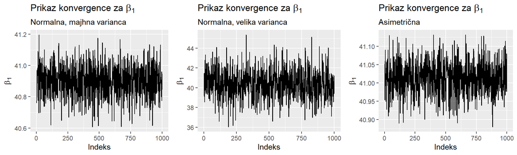

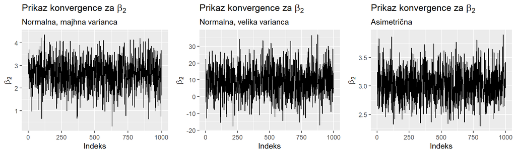

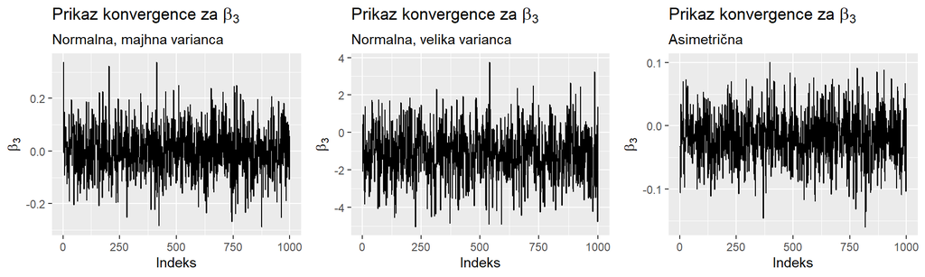

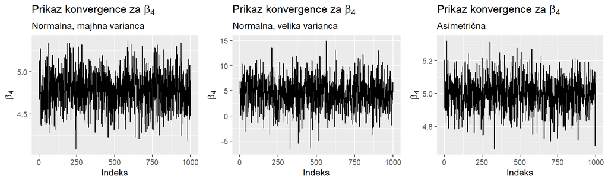

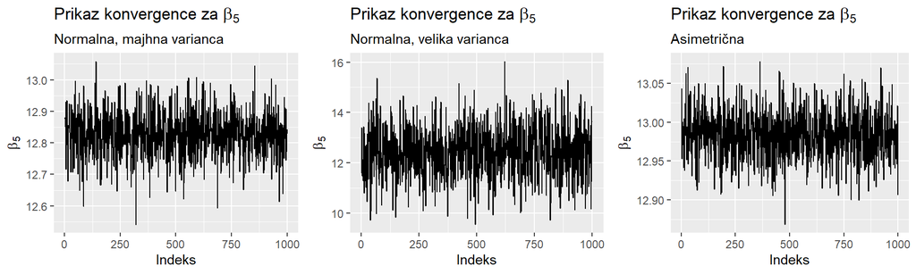

Vidimo da pri nobeni verigi ni videti težav. Poglejmo si še enake verige, le prvih $100$ členov, če bo mogoče tu opaziti če je potreben večji *burn-in*.

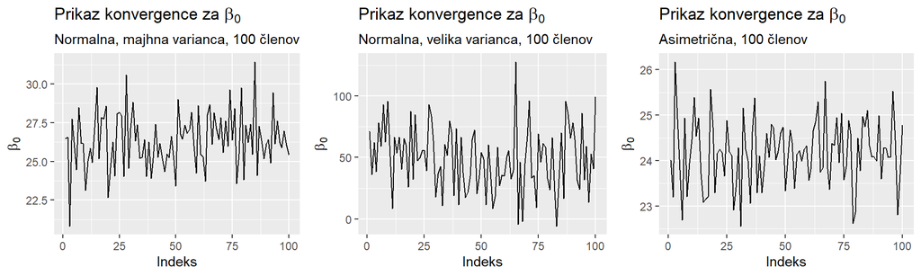

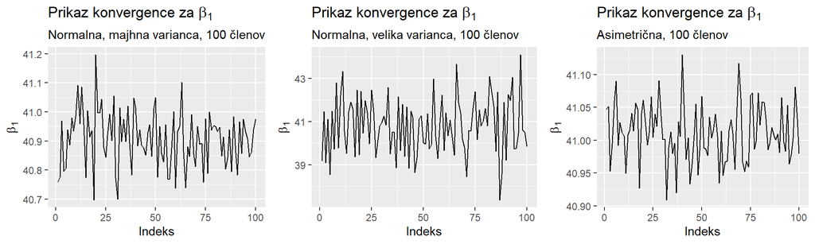

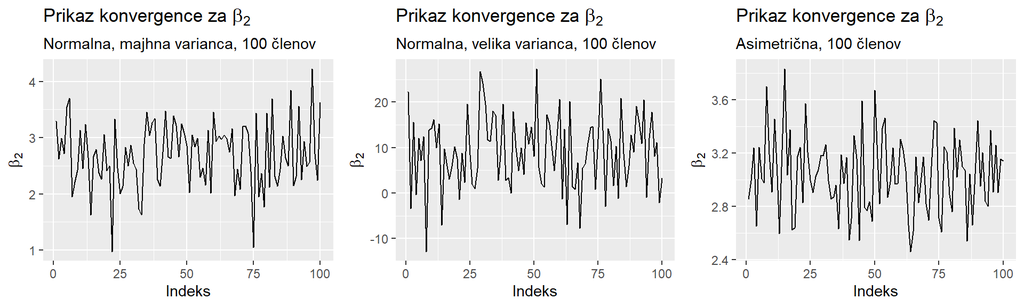

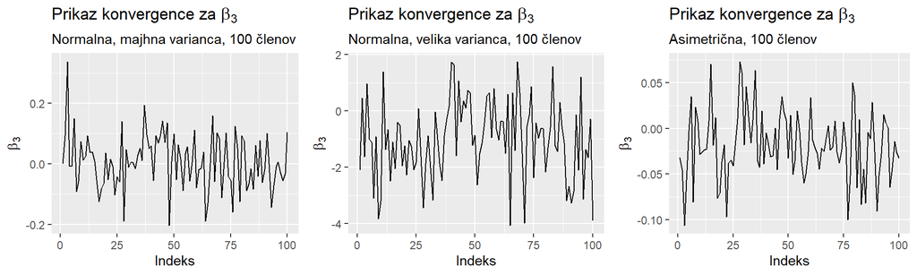

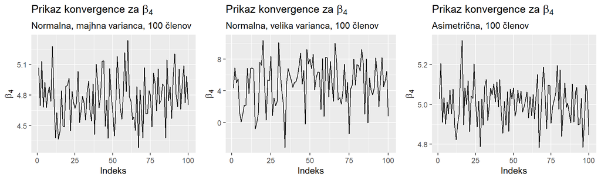

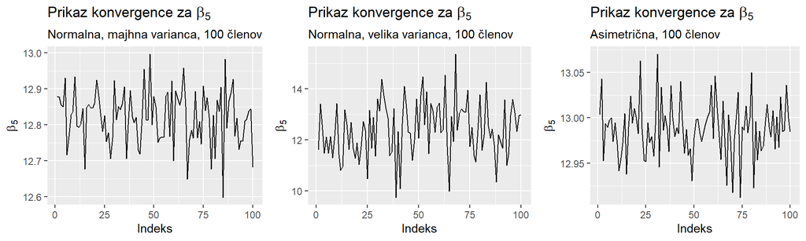

Vidimo da težav z *burn-in* nimamo. Poglejmo si še podvzorce, če mogoče vidimo manjše “premikanje”.

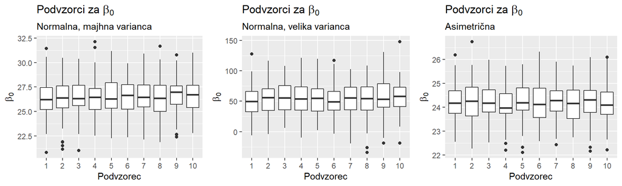

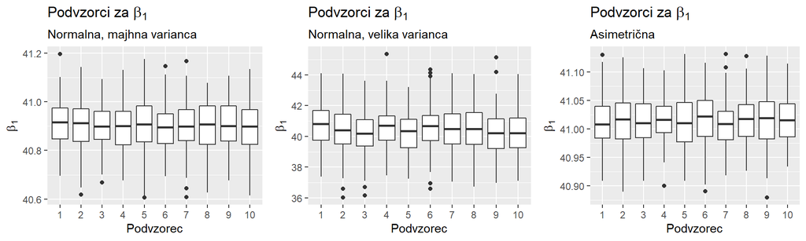

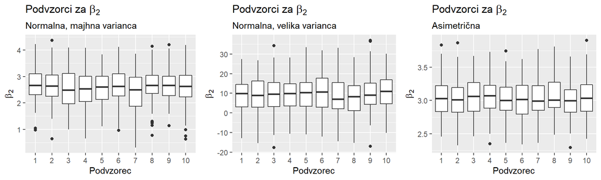

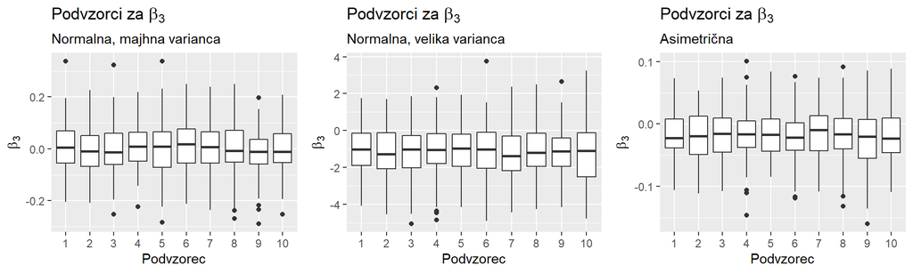

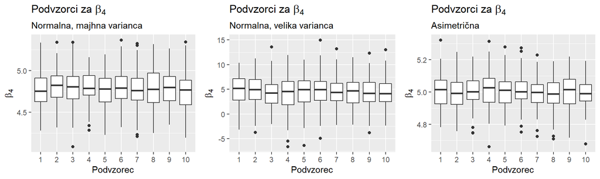

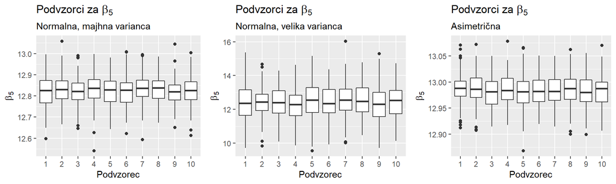

Pomemben del za preveriti je še če mogoče prihaja do avtokorelacije.

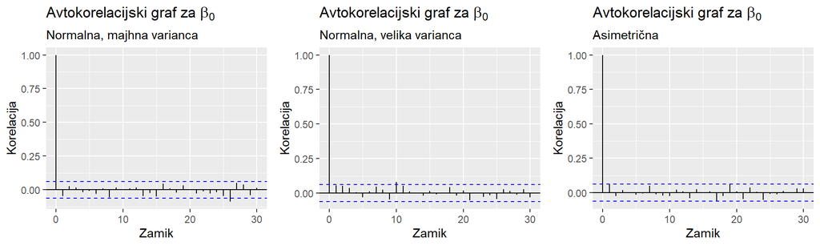

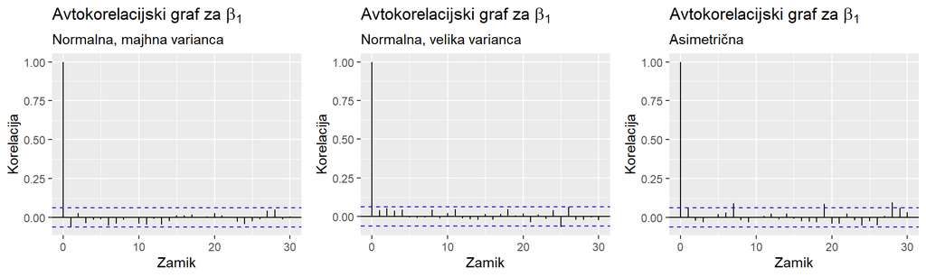

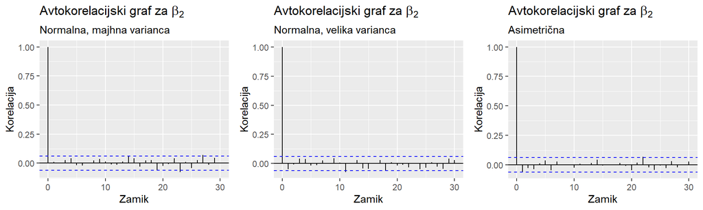

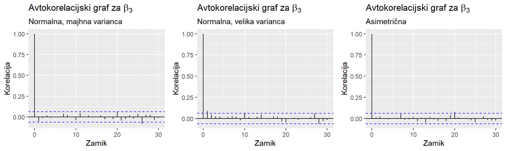

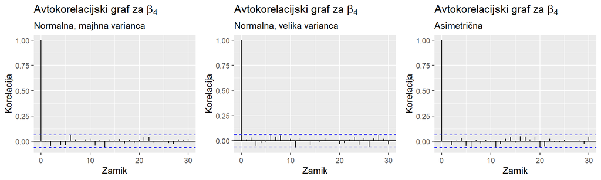

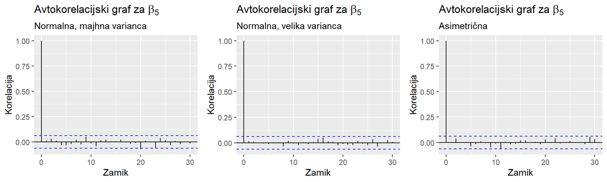

Vidimo da nimamo težav s privzetimi nastavitvami `bayesx()` funkcije, zato jih ne bomo spreminjali.

Sedaj si poglejmo primerjave med načinoma linearne regresije. Pri vseh treh primerih bomo merili pristranost kot absolutno razliko med izračunanim koeficientom iz simulacij in pravo vrednostjo koeficienta. Poleg tega bomo preverjali še standardno napako in RMSE ocen koeficientov ter povprečno ocenjeno standardno napako.

## Normalna napaka z majhno varianco

| Beta | Točne vrednosti | lm() ocena | Absolutna razlika lm() | bayesx() ocena | Absolutna razlika bayesx() |
| --- | --- | --- | --- | --- | --- |
| 0 | 23.00 | 22.98067 | 0.01933 | 22.98118 | 0.01882 |
| 1 | 41.00 | 41.00298 | 0.00298 | 41.00292 | 0.00292 |
| 2 | 3.00 | 3.00677 | 0.00677 | 3.00700 | 0.00700 |
| 3 | 0.01 | 0.00748 | 0.00252 | 0.00751 | 0.00249 |
| 4 | 5.00 | 4.99991 | 0.00009 | 4.99982 | 0.00018 |
| 5 | 13.00 | 13.00040 | 0.00040 | 13.00043 | 0.00043 |

Vidimo da pri nobenem koeficientu ni večjih odstopanj (z izjemo $\beta_0$). Oba načina pri vseh koeficientih odstopata v enako smer, in razlike so vidne šele na tretjem ali več decimalnem mestu. Tu težko razglasim “zmagovalca”, vendar je tu opaziti da `bayesx()` nekoliko manj odstopa kot `lm()`. Poglejmo si še standardno napako in RMSE za oba načina.

| Beta | lm() SE | lm() RMSE | bayesx() SE | bayesx() RMSE |
| --- | --- | --- | --- | --- |
| 0 | 1.56877 | 1.56889 | 1.57070 | 1.56889 |
| 1 | 0.10330 | 0.10334 | 0.10353 | 0.10334 |
| 2 | 0.60516 | 0.60520 | 0.60531 | 0.60520 |
| 3 | 0.07885 | 0.07889 | 0.07897 | 0.07889 |
| 4 | 0.15951 | 0.15951 | 0.15944 | 0.15951 |
| 5 | 0.06291 | 0.06291 | 0.06305 | 0.06291 |

| Beta | Povprečje lm() SE | Povprečje bayesx() SE |
| --- | --- | --- |
| 0 | 1.53694 | 1.58767 |
| 1 | 0.10290 | 0.10633 |
| 2 | 0.62656 | 0.64757 |
| 3 | 0.07704 | 0.07965 |
| 4 | 0.15886 | 0.16421 |
| 5 | 0.06179 | 0.06393 |

Ponovno vidimo da večjih razlik med načinoma ni. Pri `lm()` je SE napaka v večini primerov nižja. RMSE je praktično enak v vseh treh primerih. Mogoče bo zgodba drugačna pri normalni napaki z veliko varianco.

## Normalna napaka z veliko varianco

| Beta | Točne vrednosti | lm() ocena | Absolutna razlika lm() | bayesx() ocena | Absolutna razlika bayesx() |
| --- | --- | --- | --- | --- | --- |
| 0 | 23.00 | 23.72190 | 0.72190 | 23.71353 | 0.71353 |
| 1 | 41.00 | 40.99719 | 0.00281 | 40.99690 | 0.00310 |
| 2 | 3.00 | 3.18467 | 0.18467 | 3.19956 | 0.19956 |
| 3 | 0.01 | -0.01550 | 0.02550 | -0.01499 | 0.02499 |
| 4 | 5.00 | 4.92971 | 0.07029 | 4.92673 | 0.07327 |
| 5 | 13.00 | 12.97226 | 0.02774 | 12.97212 | 0.02788 |

Podobno kot prej, tudi tu sta si oba načina zelo blizu. Ponovno oboje odstopa v enako smer. Nekoliko boljši rezultati so pri `lm()` vendar večjih razlik ni videti.

| Beta | lm() SE | lm() RMSE | bayesx() SE | bayesx() RMSE |
| --- | --- | --- | --- | --- |
| 0 | 25.38000 | 25.39026 | 25.36341 | 25.39026 |
| 1 | 1.72596 | 1.72596 | 1.72630 | 1.72596 |
| 2 | 10.20725 | 10.20892 | 10.23092 | 10.20892 |
| 3 | 1.29564 | 1.29589 | 1.29568 | 1.29589 |
| 4 | 2.56992 | 2.57089 | 2.56815 | 2.57089 |
| 5 | 1.06811 | 1.06847 | 1.06854 | 1.06847 |

| Beta | Povprečje lm() SE | Povprečje bayesx() SE |
| --- | --- | --- |
| 0 | 25.65943 | 25.93770 |
| 1 | 1.71414 | 1.73328 |
| 2 | 10.44167 | 10.54559 |
| 3 | 1.28628 | 1.30075 |
| 4 | 2.62736 | 2.65315 |
| 5 | 1.03277 | 1.04431 |

Večjih razlik ni videti. RMSE je zopet praktično enak, medtem ko so standardne napake v 4ih primerih nižje pri `lm()`. Povprečna SE je bila v vseh primerih nižja kot pri `bayesx()`.

## Asimetrična napaka

| Beta | Točne vrednosti | lm() ocena | Absolutna razlika lm() | bayesx() ocena | Absolutna razlika bayesx() |
| --- | --- | --- | --- | --- | --- |
| 0 | 23.00 | 23.98620 | 0.98620 | 23.98613 | 0.98613 |
| 1 | 41.00 | 41.00198 | 0.00198 | 41.00193 | 0.00193 |
| 2 | 3.00 | 3.00341 | 0.00341 | 3.00267 | 0.00267 |
| 3 | 0.01 | 0.00911 | 0.00089 | 0.00917 | 0.00083 |
| 4 | 5.00 | 5.00351 | 0.00351 | 5.00354 | 0.00354 |
| 5 | 13.00 | 13.00038 | 0.00038 | 13.00040 | 0.00040 |

| Beta | lm() SE | lm() RMSE | bayesx() SE | bayesx() RMSE |
| --- | --- | --- | --- | --- |
| 0 | 0.74789 | 1.23771 | 0.75060 | 1.23771 |
| 1 | 0.05103 | 0.05107 | 0.05109 | 0.05107 |
| 2 | 0.29914 | 0.29916 | 0.29926 | 0.29916 |
| 3 | 0.03728 | 0.03729 | 0.03740 | 0.03729 |
| 4 | 0.07844 | 0.07852 | 0.07857 | 0.07852 |
| 5 | 0.02944 | 0.02945 | 0.02947 | 0.02945 |

| Beta | Povprečje lm() SE | Povprečje bayesx() SE |
| --- | --- | --- |
| 0 | 0.72282 | 0.80523 |
| 1 | 0.04847 | 0.05401 |
| 2 | 0.29447 | 0.32840 |
| 3 | 0.03632 | 0.04046 |
| 4 | 0.07388 | 0.08225 |
| 5 | 0.02907 | 0.03230 |

SE in povprečna standardna napaka je zopet boljša pri `lm()`, vendar sumim, da je vzrok za to majhno št. simulacij.

`bayesx()` se pokaže kot boljša izbira za ocenjevanje $\beta$ koeficientov pri asimetrični porazdelitvi napake, medtem ko je `lm()` način boljši z vidika standardne napake, ter v primerih normalne napake.

Kar se tiče uporabnosti metod se mi zdi da je, glede na te rezultate, `lm()` boljši način (za linearno regresijo). Osebno se mi zdi da so Bayesovi načini precej boljši pri drugačnih problemih, kot npr. že obdelani hierarhični modeli.

# Analiza podatkov

Podatke sem po naključju našel, ko sem razmišljal kakšne podatke uporabiti za predstavitev pri predmetu *Napredni pristopi v programskem okolju R*. Podatki so dosegljivi na profilu RodolfoViana na spletni strani github. (https://github.com/RodolfoViana/exploratory-data-analysis-dataset-cars). Kasneje sem se odločil da bom te podatke uporabil za ta predmet, saj se mi zdi da so bili dober primer podatkov za hierarhični model.

Podatki predstavljajo modele avtomobilov med leti 1970 in 1982, saj se je ameriška proizvodnja avtomobilov v tem obdobju začela premikati stran od $6$ in $8$ valjnikov s predvsem slabo ekonomičnostjo na k lažjim, manj močnim in bolj ekonomičnimi $4$ valjnimi motorji. Podatki vsebujejo naslednje spremenljivke:

- *ID* - zaporedna oznaka avtomobila v podatkih
- *mpg* - ekonomičnost/poraba avtomobila (v miljah na galono)
- *cylinders* - št. cilindrov
- *displacement* - prostornina motorja
- *horsepower* - Moč motorja (v konjskih močeh)
- *weight* - Teža avtomobila
- *acceleration* - Pospešek avtomobila
- *model* - Letnik avtomobila (modelsko leto)
- *origin* - Poreklo avtomobila
- *car-name* - Ime avtomobila
- *price* - Cena avtomobila (v dolarjih)

Kar se samega čiščenja podatkov tiče, nekaj zapisov je imelo v spremenljivki *horsepower* zapis “?” ter nekaj zapisov pri spremenljivki *car-name* je imelo tiskarske napake. Takšne zapise sem odstranil. Avtomobile sem nekoliko “poenostavil” do te mere, da ne gledamo specifičnega avtomobila, temveč le znamko (npr. Toyota, Ford, …). Po čiščenju ostane 385 zapisov.

Z linearnim modelom bomo poskušali napovedati ceno (*price*) avtomobila na podlagi spremenljivk *mpg*, *horsepower* in *weight*. Te spremenljivke sem si izbral, saj sumim da sta *mpg* in *horsepower* korelirana (večji *mpg* pomeni manjši *horsepower*) in me posledično zanima kako se Bayesov linearni model obnese v takšni situaciji. Predpostavljam da je *weight* nekoliko povezan tudi z velikostjo avtomobila in mislim da so večji avtomobili v večini primerov tudi dražji. Poglejmo si najprej opisne statistike izbranih spremenljivk ter njihove porazdelitve

|  | mean | sd | median | mad | min | max | range | skew | kurtosis | se |
| --- | --- | --- | --- | --- | --- | --- | --- | --- | --- | --- |
| price | 29619.78 | 9878.18 | 30000.0 | 9753.65 | 1598.07 | 53745.94 | 52147.86 | 0.02 | -0.29 | 503.44 |
| mpg | 23.45 | 7.81 | 22.4 | 8.75 | 10.00 | 46.60 | 36.60 | 0.47 | -0.54 | 0.40 |
| horsepower | 104.61 | 38.42 | 95.0 | 29.65 | 46.00 | 230.00 | 184.00 | 1.07 | 0.65 | 1.96 |
| weight | 2981.63 | 846.73 | 2815.0 | 934.04 | 1613.00 | 5140.00 | 3527.00 | 0.51 | -0.83 | 43.15 |

Vidimo da je cena skoraj normalno porazdeljena (*skewness* in *kurtosis*) medtem ko so napovedne spremenljivke nekoliko asimetrične, kjer je *weight* tudi nekoliko sploščena. Poglejmo si še porazdelitve ter posamezne kombinacije spremenljivk.

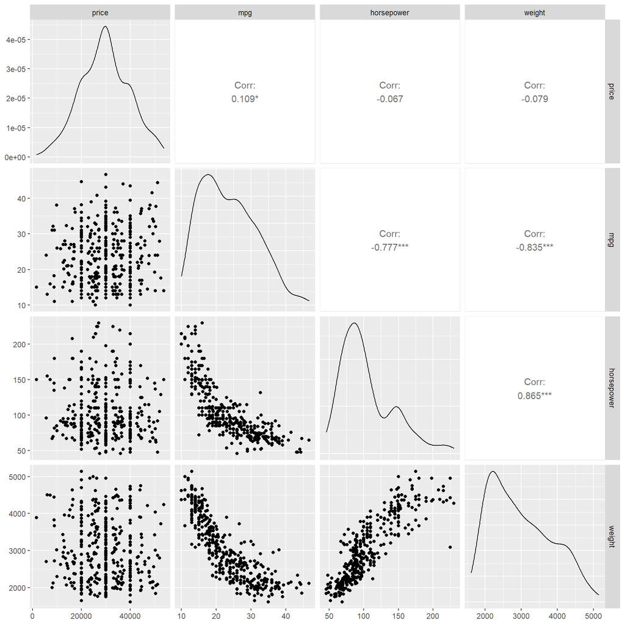

Vidimo da je *price* precej nekoreliran z ostalimi spremenljivkami, medtem ko so ostale zelo korelirane. Izgleda da sta *mpg* in *horsepower* precej bolj linearno povezana v logaritemskem prostoru, vendar se ne bom spuščal v to.

Linearen model bo oblike

$$price = \beta_0 + \beta_1mpg + \beta_2horsepower + \beta_3weight$$
Torej poskusili bomo določiti ceno na podlagi ekonomičnosti, moči motorja in teže avtomobila. Najprej si poglejmo grafe verig za naše koeficiente.

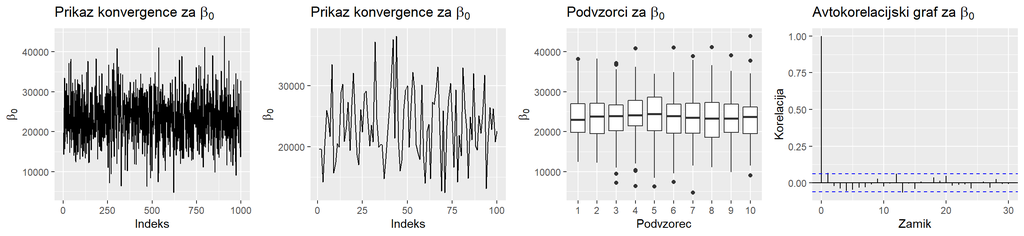

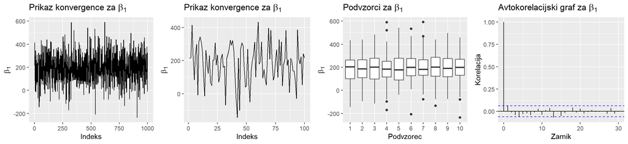

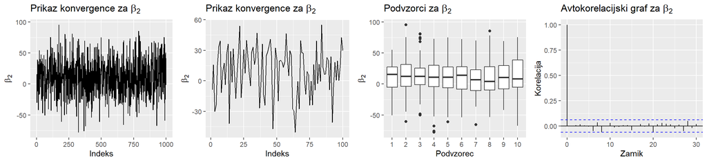

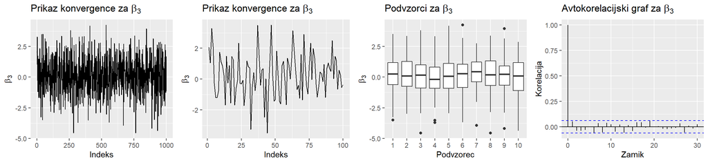

Vidimo da so vsi grafi vredu in ni potrebno dodatno spreminjati parametrov zato si poglejmo porazdelitve in vrednosti naših koeficientov.

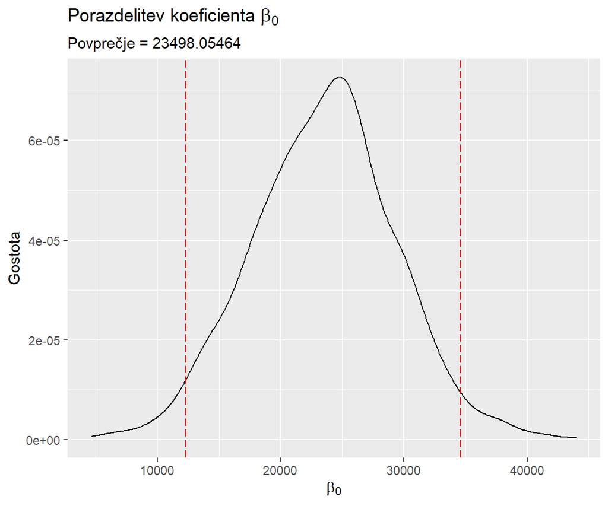

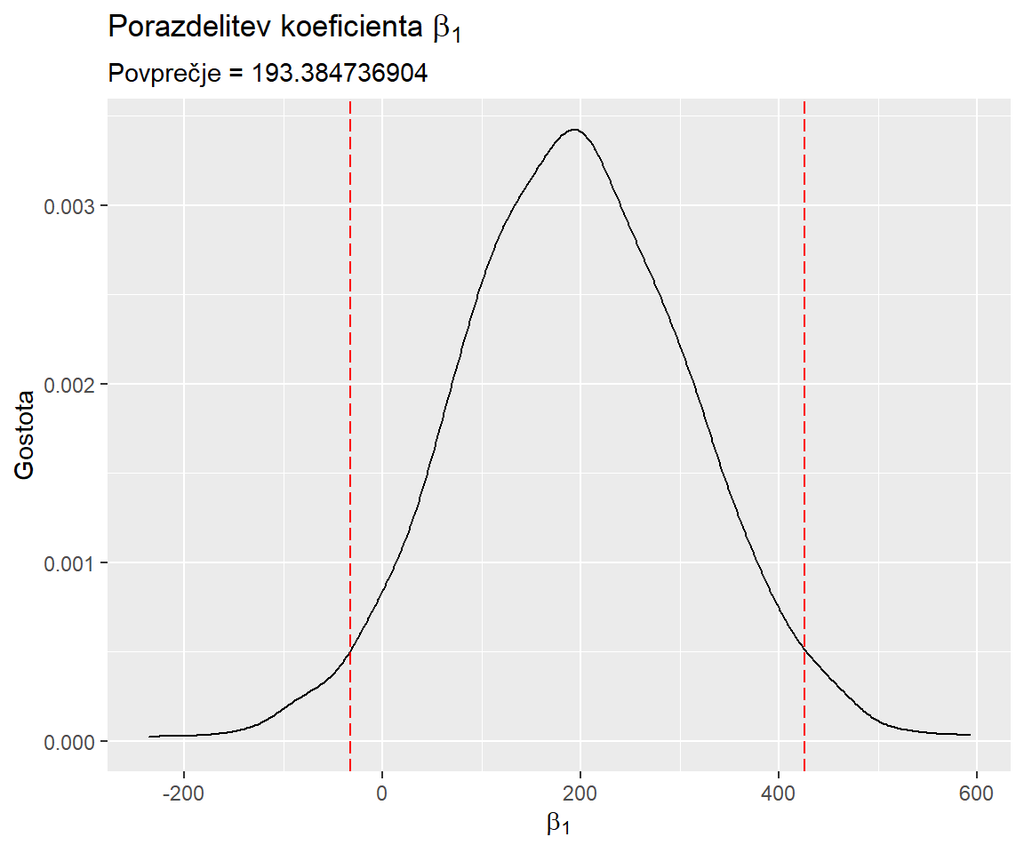